# Recommending Top-N movies - Part 2: Testing recommendation algorithms

In part 1 of this project, we looked at the MovieLens data set and implemented algorithms to recommend movies based off of this. We took a brief look at some of these algorithms parameters and differences in runtime. In this part of the project, we will use various metrics to test the accuracy and validity of the recommended movies using a train-test-validation split of the reduced data set.

To do this we'll use three new classes: SplitData, Metrics, and Tester which split the ratings pivot data frame, run metrics on the recommendations, and run tests over multiple users respectively. More documentation for these classes can be found in the MovieLensData.py and Tester.py files, with further information on the algorithms in the Algorithms.py file.

## Preparing the Data

- Creating the ratings pivot data frame
- Splitting the data for testing
- Building the models

We'll start by importing the required packages and building the ratings pivot data frame from a reduced set of data. As discussed in the part 1, we're sampling users with rating counts between 200-6000 and limiting movies to those with more than 100 ratings to avoid biases from outliers and to work within the constraints of computing power available. However, as the tests are very computationally intensive, I will initially be reducing this further by taking a random sample of 10% of the reduced userIDs.

```python
import pandas as pd
import seaborn as sns
import matplotlib.pyplot as plt
from ast import literal_eval
import importlib
import random
import MovieLensData
import Algorithms
import Tester

import warnings
warnings.filterwarnings('ignore')
sns.set()
```

```python
ml = MovieLensData.MovieLensData()
userIDs = ml.filterIDs('userId', minRatings=200, maxRatings=6000)
movieIDs = ml.filterIDs('movieId', minRatings=100)
userIDs = random.sample(userIDs, int(0.1 * len(userIDs)))
ml.reduce(userIDs, 'userId', 'ratings')
ml.reduce(movieIDs, 'movieId', 'movies')

ratingsData = ml.buildPivot(printStats=True)
```

```
Loading data... Done
Building movies/ratings pivot df... Done
3528 / 283228 users retained (1.25%)
10500 / 58098 movies retained (18.07%)
1652971 / 27753444 ratings retained (5.96%)
95.54% sparsity
```

The SplitData class splits up the ratings pivot data frame into a trainSet and testSet_full. testSet_full is then split in two ways: one into a a test-validation split where every user in testSet_full has a percentage or number of ratings split off into the validation set, and one that takes away just one rating from each user for leave-one-out cross validation (LOO-CV). The size of testSet_full and validation sets are governed by the testSize and validationSize parameters respectively. As the data is relatively large, we afford to keep more users in the train set, so 20% splits will be used for both the testSize and validationSize parameters.

The ratings in the test set are used to generate recommendations, with the two validation sets used to check the quality of recommendations against various metrics. We can ensure the same splits occur each time via the randomState parameter for consistency in results reporting.

```python
train, test, validation, LOO_test, LOO_dropped = MovieLensData.SplitData(ratingsData).buildAll(testSize=0.2,
                                                                                               validationSize=0.2,
                                                                                               randomState=20)
```

```
Building train/test/validation split by row... Done
Building LeaveOneOut-CrossValidation data... Done
```

As seen in the previous part, we can easily build each model by calling the buildModel method in the Algorithm class. This time, we initialise the method by passing the train and test set data so the program knows which set to build the model from, and which to use to look up ratings for testing. We will also need to call the buildMatrix method to generate the sparse matrix for building the KNN models.

However, this time we will not need to generate a similarity matrix for the users. As these models are built off of the train set and we will not be testing any f the userIDs in this set, we do not need to build a user similarity matrix for the CF algorithm and can simply pass 'None' as the model parameter when testing this algorithm.

```python
algo = Algorithms.Algorithms(ml, train, test)
ratingsSparse = algo.buildMatrix()
printStatus = True

CF_itemModel = algo.buildModel(modelType='CF', matrix='item', printStatus=printStatus)
KNN_itemModel = algo.buildModel(modelType='KNN', matrix=ratingsSparse.transpose(), printStatus=printStatus)
KNN_userModel = algo.buildModel(modelType='KNN', matrix=ratingsSparse, printStatus=printStatus)
```

```
Initialising object... Done
Building sparse matrix... Done

Building CF model
Correlating ratings for all movies... Done
Correlating genres for all movies... Done
Correlating years for all movies... Done
Generating combined correlation... Done
Done. Time: 15.116445400000003s

Building KNN model
Done. Time: 0.023184799999995676s

Building KNN model
Done. Time: 0.006436299999997175s
```

## Testing Demonstration and Metrics

- Adding algorithms for testing
- Running basic and parameter tests
- MAE, RMSE, Coverage, Diversity, Novelty, Hit Rates (Validation, LOO-CV, Cumulative, Mean Reciprocal, Actual Rating)

### Working with the Tester class

The Metrics class contains the various metrics we'll be using the test the quality of our results. This takes the validation and LOO-CV sets to check the results against, a filename for the csv that stores the results, as well as various parameters for testing (discussed below).

This object is then passed to the Tester class to create our test object. This object has two primary methods for testing, runBasicTest and runParameterTest, as well as two methods for adding and removing algorithms. All we need to do to set up tests is to instantiate the tester object, and pass the various algorithms' names, method to call, model and all other parameters to control for this test. The parameters we control will be discussed in greater detail when discussing results later in this notebook.

Here we'll also add a random control algorithm which simply generates random similarity scores and random rating predictions for every user. The randomRatings parameter of this method determines whether or not the rating predictions are a random number between 0-5 independent of the similarity scores, or if the rating predictions are a multiple of the randomly generated similarity scores.

```python
filename = 'ML_MetricsData_sample'
evaluator = Tester.Metrics(validation, LOO_dropped, topN=10, moviesPerPage=5, thresholdRating=3.0, csvName=filename)
tester = Tester.Tester(evaluator)

neighbours = 100
sample = 100
thresh = 2.0

tester.addAlgorithm('Item-Based CF', algo.itemBased, model=CF_itemModel, modelType='CF', neighbours=neighbours,
                    sample=sample, threshold=thresh, predict='calc')
tester.addAlgorithm('User-Based CF', algo.userBased, model=None, modelType='CF', neighbours=neighbours,
                    sample=sample, threshold=thresh, predict='calc')
tester.addAlgorithm('Item-Based KNN', algo.itemBased, model=KNN_itemModel, modelType='KNN', neighbours=neighbours,
                    sample=sample, threshold=thresh, predict='calc')
tester.addAlgorithm('User-Based KNN', algo.userBased, model=KNN_userModel, modelType='KNN', neighbours=neighbours,
                    sample=sample, threshold=thresh, predict='calc')
tester.addAlgorithm('Random Control', algo.random, randomRatings=True)
```

[output not shown]

With the algorithms loaded, we can now run a simple test using the test set. The runBasicTest takes a few key arguments:

- testData - the test set
- testAlgo - the name of the algorithm from the dictionary of loaded algorithms to test
- sampleTest - the number of users from the test to sample
- param, pValue - the parameter and its value to modify from the stored parameters within the object

Here we run a simply test on the above using the stored algorithms for 10 randomly sample users in the test set.

```python
tester.runBasicTest(test, sampleTest=10)
```

The LeaveOneOut cross validation metric uses a different set of ratings per user and is therefore needs to be identified when initialising tests. We can define this by setting LOOCV to True. This usually defaults to False, testing the results against the validation HitRate metric instead (metric types discussed below).

```python
tester.runBasicTest(LOO_test, LOOCV=True, sampleTest=10)
```

The runParameterTest method allows us to iterate through a range of values for a given parameter. The parameter is passed to the runBasicTest to run tests across the users present in the test set. This allows us to see the effect of changing parameters within the methods, with the aim of fine-tuning the algorithms. The parameters for this function are much the same as the runBasicTest method, with pValue now replaced with pRange as the range of parameters to test.

Here we run a basic demonstration on the 'pred' parameter which changes the rating prediction algorithm (discussed in greater in the results).

```python
parameter = 'predict'
pRange = ['rand', 'calc', 'sims', 'norm_sims']
sampleTest = 10

tester.runParameterTest(test, param=parameter, pRange=pRange, sampleTest=sampleTest, printResults=False)
```

By calling the readCSV method in the evaluator class, we can see the results we have just generated ready for analysis.

```python
evaluator.readCSV(filename).head(20)
```

|  | Algorithm | Top-N | MoviesPerPage | ThresholdRating | TotalIDs | ParameterTest | ParameterValue | OtherParameters | TotalTime/s | MeanTime/s | MAE | RMSE | Coverage | Diversity | Novelty | LOOCV_HR | Validation_HR | Cumulative_HR | MeanReciprocal_HR | ActualRating_HR |
| --- | --- | --- | --- | --- | --- | --- | --- | --- | --- | --- | --- | --- | --- | --- | --- | --- | --- | --- | --- | --- |
| 0 | Item-Based CF | 10 | 5 | 3 | 10 | NaN | NaN | {'neighbours': 100, 'sample': 100, 'threshold'... | 1.093928 | 0.109393 | 0.590087 | 0.646977 | 0.306962 | 0.344359 | 0.076681 | NaN | 0.21 | 0.21 | 0.175 | {2.0: 0.000819672131147541, 3.0: 0.00880455407... |
| 1 | User-Based CF | 10 | 5 | 3 | 10 | NaN | NaN | {'neighbours': 100, 'sample': 100, 'threshold'... | 13.605833 | 1.360583 | 0.349836 | 0.391245 | 0.221848 | 0.438315 | 0.004450 | NaN | 0.17 | 0.17 | 0.120 | {3.5: 0.0029213955443463642, 4.0: 0.0075286138... |
| 2 | Item-Based KNN | 10 | 5 | 3 | 10 | NaN | NaN | {'neighbours': 100, 'sample': 100, 'threshold'... | 60.645003 | 6.064500 | 0.677091 | 0.679859 | 0.111914 | 0.179893 | 0.003070 | NaN | 0.10 | 0.10 | 0.075 | {3.0: 0.0032903643050143315, 4.0: 0.0010526315... |
| 3 | User-Based KNN | 10 | 5 | 3 | 10 | NaN | NaN | {'neighbours': 100, 'sample': 100, 'threshold'... | 6.682255 | 0.668226 | 0.753723 | 0.803360 | 0.122867 | 0.454609 | 0.009551 | NaN | 0.26 | 0.22 | 0.225 | {1.5: 0.0006134969325153375, 2.0: 0.0021276595... |
| 4 | Random Control | 10 | 5 | 3 | 10 | NaN | NaN | {'randomRatings': True} | 0.162845 | 0.016285 | 0.000000 | 0.000000 | 1.000000 | 0.000531 | 0.543995 | NaN | 0.00 | 0.00 | 0.000 | {} |
| 5 | Item-Based CF | 10 | 5 | 3 | 10 | NaN | NaN | {'neighbours': 100, 'sample': 100, 'threshold'... | 1.104494 | 0.110449 | 0.564364 | 0.671683 | 0.280952 | 0.343810 | 0.071127 | 0.0 | NaN | 0.22 | 0.170 | {2.0: 0.002173913043478261, 3.0: 0.00653517759... |
| 6 | User-Based CF | 10 | 5 | 3 | 10 | NaN | NaN | {'neighbours': 100, 'sample': 100, 'threshold'... | 13.751851 | 1.375185 | 0.365606 | 0.399532 | 0.216019 | 0.385336 | 0.007110 | 0.0 | NaN | 0.15 | 0.120 | {3.0: 0.002000788488074118, 3.5: 0.00112359550... |
| 7 | Item-Based KNN | 10 | 5 | 3 | 10 | NaN | NaN | {'neighbours': 100, 'sample': 100, 'threshold'... | 63.217344 | 6.321734 | 0.404854 | 0.404854 | 0.147590 | 0.141935 | 0.001882 | 0.0 | NaN | 0.09 | 0.070 | {3.0: 0.00196078431372549, 4.0: 0.004290932799... |
| 8 | User-Based KNN | 10 | 5 | 3 | 10 | NaN | NaN | {'neighbours': 100, 'sample': 100, 'threshold'... | 6.825581 | 0.682558 | 1.038975 | 1.085616 | 0.150381 | 0.355712 | 0.007172 | 0.0 | NaN | 0.23 | 0.175 | {1.0: 0.0011627906976744186, 1.5: 0.0029171766... |
| 9 | Random Control | 10 | 5 | 3 | 10 | NaN | NaN | {'randomRatings': True} | 0.159490 | 0.015949 | 0.000000 | 0.000000 | 1.000000 | 0.000485 | 0.490019 | 0.0 | NaN | 0.00 | 0.000 | {} |
| 10 | Item-Based CF | 10 | 5 | 3 | 10 | predict | rand | {'neighbours': 100, 'sample': 100, 'threshold'... | 1.225513 | 0.122551 | 1.851563 | 2.132115 | 0.301229 | 0.355657 | 0.080890 | NaN | 0.28 | 0.09 | 0.190 | {1.0: 0.004166666666666667, 2.5: 0.00161290322... |
| 11 | User-Based CF | 10 | 5 | 3 | 10 | predict | rand | {'neighbours': 100, 'sample': 100, 'threshold'... | 13.655486 | 1.365549 | 0.840567 | 0.908513 | 0.237981 | 0.368817 | 0.004180 | NaN | 0.13 | 0.03 | 0.100 | {3.0: 0.0017543859649122805, 3.5: 0.0037543859... |
| 12 | Item-Based KNN | 10 | 5 | 3 | 10 | predict | rand | {'neighbours': 100, 'sample': 100, 'threshold'... | 62.293561 | 6.229356 | 1.581315 | 1.609300 | 0.143343 | 0.153480 | 0.007868 | NaN | 0.10 | 0.05 | 0.080 | {2.0: 0.0027777777777777775, 3.5: 0.0038712686... |
| 13 | User-Based KNN | 10 | 5 | 3 | 10 | predict | rand | {'neighbours': 100, 'sample': 100, 'threshold'... | 6.811256 | 0.681126 | 1.369214 | 1.432026 | 0.142790 | 0.400323 | 0.005965 | NaN | 0.18 | 0.11 | 0.160 | {1.0: 0.0014705882352941176, 2.5: 0.0007462686... |
| 14 | Item-Based CF | 10 | 5 | 3 | 10 | predict | calc | {'neighbours': 100, 'sample': 100, 'threshold'... | 1.092454 | 0.109245 | 0.605490 | 0.760722 | 0.314838 | 0.345629 | 0.075653 | NaN | 0.23 | 0.23 | 0.180 | {2.0: 0.0007518796992481202, 2.5: 0.0023809523... |
| 15 | User-Based CF | 10 | 5 | 3 | 10 | predict | calc | {'neighbours': 100, 'sample': 100, 'threshold'... | 13.710756 | 1.371076 | 0.598623 | 0.625537 | 0.217667 | 0.463848 | 0.005815 | NaN | 0.22 | 0.22 | 0.165 | {2.5: 0.0013157894736842105, 3.0: 0.0023529411... |
| 16 | Item-Based KNN | 10 | 5 | 3 | 10 | predict | calc | {'neighbours': 100, 'sample': 100, 'threshold'... | 62.272036 | 6.227204 | 0.176121 | 0.176121 | 0.136952 | 0.167021 | 0.002170 | NaN | 0.05 | 0.05 | 0.040 | {2.5: 0.002173913043478261, 3.5: 0.00227272727... |
| 17 | User-Based KNN | 10 | 5 | 3 | 10 | predict | calc | {'neighbours': 100, 'sample': 100, 'threshold'... | 6.722564 | 0.672256 | 0.680657 | 0.701166 | 0.122762 | 0.437059 | 0.005694 | NaN | 0.21 | 0.21 | 0.170 | {2.0: 0.0030638297872340424, 3.0: 0.0006451612... |
| 18 | Item-Based CF | 10 | 5 | 3 | 10 | predict | sims | {'neighbours': 100, 'sample': 100, 'threshold'... | 1.075191 | 0.107519 | 0.696024 | 0.762412 | 0.310981 | 0.347479 | 0.082290 | NaN | 0.25 | 0.17 | 0.200 | {3.0: 0.007597063967160636, 3.5: 0.00997442972... |
| 19 | User-Based CF | 10 | 5 | 3 | 10 | predict | sims | {'neighbours': 100, 'sample': 100, 'threshold'... | 13.557014 | 1.355701 | 0.740127 | 0.772587 | 0.218229 | 0.429984 | 0.005673 | NaN | 0.16 | 0.03 | 0.125 | {0.5: 0.0004098360655737705, 2.5: 0.0004098360... |

### Metrics and the Metrics class

The recommendations for each userID are passed to the an instantiate object of the Metrics class for evaluation. It runs various tests and saves the results to a csv file for later analysis. It requires a few parameters upon initialisation to run the tests:

- Top-N: the top number of recommendations to consider (used by all metrics bar coverage)
- moviesPerPage: the number of movies that will appear per page for the end-user, used only by the meanReciprocalHR metric)
- thresholdRating: the minimum rating to be considered by the cumulativeHR metric

Below is a full list and description of the metrics used for testing.

#### MAE

Error on the predicted ratings from actual ratings. Calculated by taking the absolute difference between the predicted and actual ratings for every hit and finding the mean of these errors. Can range from 0 to infinite. Lower values show a more accurate set of rating predictions.

#### RMSE

Error on the predicted ratings from actual ratings. RMSE gives a higher weight to larger errors and an indication of the increase in variance of the frequency distribution of error magnitudes. Due to this, it will always be equal to or greater than MAE.

RMSE is found by squaring the difference between predicted and actual ratings for hits, finding the mean of these and finally square rooting. Can range from 0 to infinite. Lower values show a more accurate set of rating predictions, with values similar to the MAE value showing less variation of the distribution of errors.

#### Coverage

The number of total movies from the data set the algorithm is able to recommend to the user. Ignores Top-N, dividing the total number of movies in the results by the movies available in the training set. Expressed as a percentage in decimal form ranging from 0 to 1.

Higher coverage values are preferred to ensure the algorithm is accessing the full extent of the items available.

#### Diversity

How diverse the Top-N recommendations are i.e., are the Top-N movies very closely related (low diversity) or not (high diversity). Given by the mean of the similarities of the Top-N movies (S) subtracted from 1 (1-S). Expressed as a percentage in decimal form ranging from 0 to 1.

Very diverse recommendations are more likely to engage the user. Less diverse recommendations may just be recommending very closely related movies, like sequels of movies that the user is most likely to have already seen.

#### Novelty

How novel the Top-N movies are i.e., how much of the long-tail of less popular movies is the algorithm able to recommend in the Top-N. Found by dividing the mean of the ranks of the Top-N movies by the lowest ranked movie in the training set. Expressed as a percentage in decimal form ranging from 0 to 1.

Higher values are usually preferred however, very high values may cause a lack of trust in the recommendations from the user and cause them to disengage with the recommendation list.

#### Validation HitRate

How many movies from the Top-N recommendations are in the validation set. Simply the number of the movies from the Top-N in the validation set divided by the number of Top-N movies. Expressed as a percentage in decimal form ranging from 0 to 1. Higher values show more hits per user.

#### LeaveOneOut-CrossValidation HitRate

The number of times the algorithm recommends the movie left out for LOO-CV in the Top-N recommendations. Either 0 or 1 for every user. Higher values show more hits per user.

Difficult to achieve as the algorithm could recommend many movies the user likes, but miss the one movie left out for this validation set. Useful for smaller data sets where training and test data is limited.

#### Cumulative HitRate

Exactly the same as validation hit-rate however, we now limit the hits to only hits with a predicted rating above some threshold rating. This is to avoid giving the algorithm a positive result even if its recommendations are movies it thinks the user won't actually like.

#### Mean Reciprocal HitRate

Weights the Top-N hits by which page they appear on for a paginated recommendation system. Works just like the validation hit-rate, but now splits up hits into groups of ranks, dividing by the group number (or page) it is in. It then sums these together to give the hit-rate. Higher values show more weighted hits per user.

This is useful for system like Netflix where 5 movies are shown to a page. Our algorithm shouldn't be rewarded as highly for only recommending movies the user actually wants to watch on the last page where the user may not even see them.

#### Actual Rating HitRate

A breakdown of the hits per predicted rating given. The distribution shows us whether the algorithm tends to recommend movies it thinks the user will rate highly or not. The values can be normalised for the total movies available for each user in the validation set showing how many of the ratio for each rating it is able to correctly recommend.

A mean value can be extracted from these to show which ratings the average rating given to the hits of the Top-N recommendations. Higher values will therefore be preferred.

## Results

- Laying out the test conditions
- Testing the rating prediction parameter
- Testing the 'neighbours' parameter
- Testing the threshold rating parameter
- Testing the 'sample' parameter for item-based algorithms
- Testing the 'sample' parameter for user-based algorithms
- Runtimes

### Parameters and setting up the tests

The recommendation system assumes a 'Netflix' style end-user use case where 30 movies are shown to the user in a paginated form of 5 movies per page. We also only want to recommend movies to the user that have a predicted rating of 3.0 or more. As such, the metrics object for testing was instantiated with the parameters, topN=30, moviesPerPage=5, and thresholdRating=3.0.

The algorithms have the following parameters which can be adjusted to affect the quality of movies recommended:

- 'predict': rating prediction algorithm to use. This can be either of the following:
  - 'calc': use the formulaically calculated value which takes the sum of the weighted similarities, divided by the sum of the unweighted similarities, introduces the input user's bias, and limits to a max rating of 5.0. More information on how this works can be found in part 1.
  - 'mean': use the mean values from the train data,
  - 'sims': multiply similarity scores by max possible rating for predicted ratings,
  - 'norm_sims': normalise similarity scores then multiply by max possible rating for predicted ratings,
  - 'rand': randomly generate ratings.
- 'neighbours': the number of most similar neighbours to draw similarities from. This works slightly differently for item- or user-based algorithms.
  - Item-based: the algorithm will sample the most similar items per item the input user has rated i.e., if neighbours=100, the algorithm samples the top 100 most similar movies to each movie the input user has rated.
  - User-based: the number of most similar users to the input user.
- 'threshold': the minimum rating from the input user's ratings which will be considered by the algorithm. The algorithm will remove any movies from the input user's ratings below this value.
- 'sample': this parameter has a different use-case depending on whether the algorithm is item- or user-based.
  - Item-based: samples the top-rated movies from the input user
  - User-based: sample the most similar items per item each similar user has rated. Works similarly to the 'neighbours' parameter for item-based algorithms.

We will test each of the following parameters separately, controlling the dependant parameters with the following values: 'predict'='calc', 'threshold'=2.0, 'neighbours'=100, 'sample'=100.

A control test of random predictions will also be run as a control which works by generating random similarity scores, independently generated random ratings, and returning the 30 movies with the highest similarity scores.

A complete set of raw data can be found in *output/ML_MetricsRaw.csv*.

### Testing the quality of various rating prediction methods

Four metrics consider the quality of rating predictions: MAE, RMSE, Cumulative HitRate and Actual Rating HitRate. From the data generated, adjusting the rating predictions parameter seems to have a negligible impact on runtimes so we will not consider that here.

First, we'll import the relevant, split up depending on parameter, and consider the MAE and RMSE scores for the five rating prediction algorithms.

```python
with open('output/ML_MetricsData.csv', encoding="UTF-8") as file:  # read into data frame format
    data = pd.read_csv(file)

# extract data for each parameter and recast string numbers as ints or floats
ratingTest = data[data['ParameterTest'] == 'predict'].loc[0:290]

neighboursTest = data[data['ParameterTest'] == 'neighbours']
neighboursTest['ParameterValue'] = neighboursTest['ParameterValue'].astype(int)
neighboursTest_limit = neighboursTest[neighboursTest['ParameterValue'] < 1201]  # limit data after convergence

thresholdTest = data[data['ParameterTest'] == 'threshold']
thresholdTest['ParameterValue'] = thresholdTest['ParameterValue'].astype(float)

sampleTest = data[data['ParameterTest'] == 'sample']
sampleTest['ParameterValue'] = sampleTest['ParameterValue'].astype(int)
```

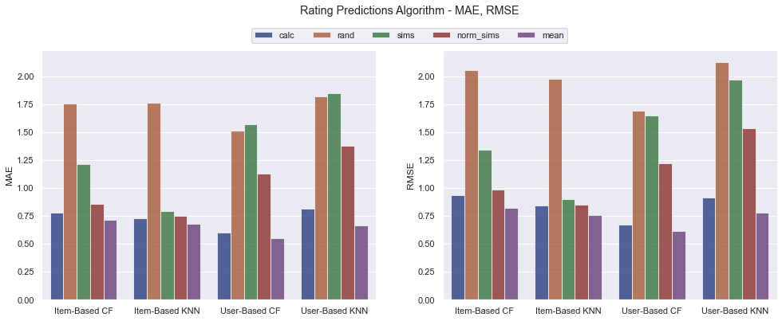

```python
# plot MAE and RMSE on subplots

fig, (ax1, ax2) = plt.subplots(1, 2, figsize=(16, 6))
ax1 = sns.barplot(data=ratingTest, x="Algorithm", y="MAE", hue="ParameterValue", palette="dark", alpha=.7, ax=ax1)
ax2 = sns.barplot(data=ratingTest, x="Algorithm", y="RMSE", hue="ParameterValue", palette="dark", alpha=.7, ax=ax2)

fig.suptitle('Rating Predictions Algorithm - MAE, RMSE')
ax1.set(xlabel=None, ylabel='MAE', ylim=(None, ax2.get_ylim()[1]))
ax2.set(xlabel=None, ylabel='RMSE', ylim=ax1.get_ylim())

fig.subplots_adjust(top=0.85, left=0.1, right=0.9)
ax1.legend(loc='center', bbox_to_anchor=(1.1, 1.06), ncol=5)
ax2.get_legend().remove()

plt.show()
fig.savefig('output/RatingPrediction_MAE+RMSE.jpg', format='jpeg', dpi=200, bbox_inches='tight')
```

As we would expect, random ratings produce the largest errors and variation in rating error. In most cases, we see that simply multiplying the similarity score by the maximum possible rating produces ratings of similar performance to random predictions. Normalising similarity scores gives slightly better results, however in user-based algorithms, these errors are still comparable to random ratings. Though in item-based algorithms, this 'normalised similarity' prediction is much more in line with the better performing algorithms.

Interestingly, we see that simply providing the overall mean rating gives the most accurate set of ratings in all cases, while the calculated value is always slightly more inaccurate. We also see RMSE only slightly above MAE in every case showing little variation in the frequency distribution of errors.

Next, we'll look at the percentage differences between the Validation HitRates (i.e. the total hits not considering ratings) and the Cumulative HitRate. This will tell us the difference between the movies predicted that the user has watched and which of those movies the ratings prediction algorithm thinks the user will actually like. For the rating predictions to be working perfectly, we would expect to see 0% difference between Validation HR and Cumulative HR.

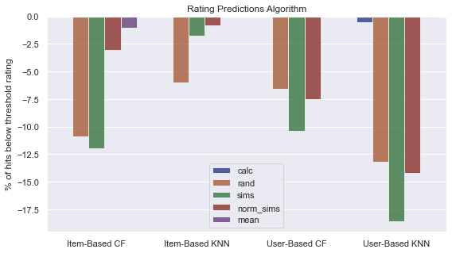

```python
# calculate drop in HitRate from validation to cumulative as a percentage
ratingTest['diffHR'] = (ratingTest['Cumulative_HR'] - ratingTest['Validation_HR']) * 100

# plot percentage differences per algorithm
fig = plt.figure(figsize=(9, 5))
ax = sns.barplot(data=ratingTest, x="Algorithm", y="diffHR", hue="ParameterValue", palette="dark", alpha=.7)
ax.set(xlabel=None, ylabel='% of hits below threshold rating', title='Rating Predictions Algorithm')
ax.legend(title=None, loc='lower center')

plt.show()
fig.savefig('output/RatingPrediction_HitsBelowThreshold.jpg', format='jpeg', dpi=200, bbox_inches='tight')
```

Here we see random-, and similarity score-based predictions returning a significant percentage of hits with ratings below 3.0, whereas calculated and mean ratings almost always give hits above 3.0. From these results, we can conclude that tuning our algorithm to give mean ratings as the rating predictions would be the best option. Furthermore, we can start to see that user-based CF provides the most accurate rating predictions for our users.

However, it may be the case that our limited data set has provided a set of users that are inherently biased toward giving ratings in line with the mean rating for that movie. As such, we will compare the calculated and mean ratings when fine-tuning the algorithms later.

### Limiting the most similar neighbours considered

The maximum number of neighbours varies for item- and user-based algorithms as being the maximum number of movies and users in the train data respectively. In this case, those values are 10500 movies and 2822 users. Due to computational limitations causing slower runtimes though, we will be considering neighbours up to 1200 for every algorithm apart from Item-Based KNN, where significantly slower runtimes mean we can only test up to 100. However, we will see from the results that the largest variance in the data occurs at these lower values, with results beginning to converge at the upper bounds of our test range.

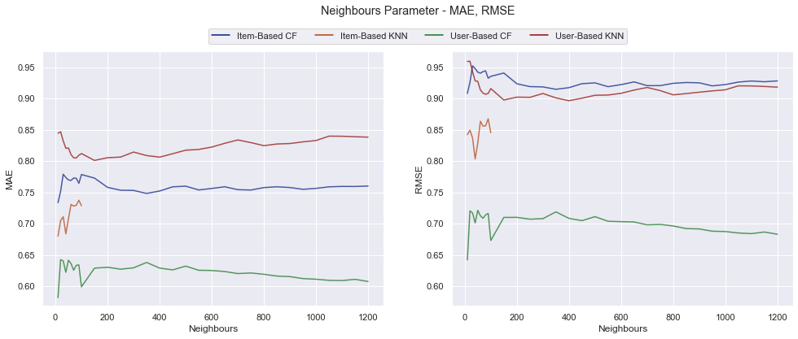

```python
# plot MAE and RMSE on subplots

fig, (ax1, ax2) = plt.subplots(1, 2, figsize=(16, 6))
ax1 = sns.lineplot(data=neighboursTest_limit, x="ParameterValue", y="MAE", hue="Algorithm", palette="dark", alpha=.7, ax=ax1)
ax2 = sns.lineplot(data=neighboursTest_limit, x="ParameterValue", y="RMSE", hue="Algorithm", palette="dark", alpha=.7, ax=ax2)

fig.suptitle('Neighbours Parameter - MAE, RMSE')
ax1.set(xlabel='Neighbours', ylabel='MAE', ylim=(None, ax2.get_ylim()[1]))
ax2.set(xlabel='Neighbours', ylabel='RMSE', ylim=ax1.get_ylim())

fig.subplots_adjust(top=0.85, left=0.1, right=0.9)
ax1.legend(loc='center', bbox_to_anchor=(1.1, 1.06), ncol=5)
ax2.get_legend().remove()

plt.show()
fig.savefig('output/Neighbours_MAE+RMSE.jpg', format='jpeg', dpi=200, bbox_inches='tight')
```

Next, we'll assess how the neighbours parameter affects the hit rate.

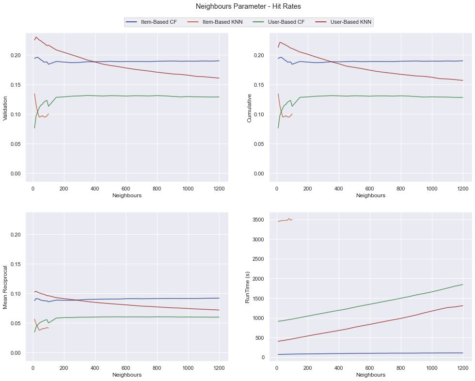

```python
# HitRates - Validation, Cumulative, Mean Reciprocal, Runtimes

fig, ((ax1, ax2), (ax3, ax4)) = plt.subplots(2, 2, figsize=(16, 12))
ax1 = sns.lineplot(data=neighboursTest_limit, x="ParameterValue", y="Validation_HR", hue="Algorithm", palette="dark", alpha=.7, ax=ax1)
ax2 = sns.lineplot(data=neighboursTest_limit, x="ParameterValue", y="Cumulative_HR", hue="Algorithm", palette="dark", alpha=.7, ax=ax2)
ax3 = sns.lineplot(data=neighboursTest_limit, x="ParameterValue", y="MeanReciprocal_HR", hue="Algorithm", palette="dark", alpha=.7, ax=ax3)
ax4 = sns.lineplot(data=neighboursTest_limit, x="ParameterValue", y="TotalTime/s", hue="Algorithm", palette="dark", alpha=.7, ax=ax4)

fig.suptitle('Neighbours Parameter - Hit Rates')
ax1.set(xlabel='Neighbours', ylabel='Validation', ylim=(-0.015, None))
ax2.set(xlabel='Neighbours', ylabel='Cumulative', ylim=ax1.get_ylim())
ax3.set(xlabel='Neighbours', ylabel='Mean Reciprocal', ylim=ax1.get_ylim())
ax4.set(xlabel='Neighbours', ylabel='RunTime (s)')

fig.subplots_adjust(top=0.91, left=0.1, right=0.9)
ax1.legend(loc='center', bbox_to_anchor=(1.1, 1.07), ncol=5)
ax2.get_legend().remove()
ax3.get_legend().remove()
ax4.get_legend().remove()

plt.show()
fig.savefig('output/Neighbours_HitRates.jpg', format='jpeg', dpi=200, bbox_inches='tight')
```

While user-based CF provides the most accurate ratings, it has some of the lowest hits according to every hit rate metric, whereas item-based CF and user-based KNN provide some of the best. It appears item-based KNN provides the least hits, but tests were deemed too impractical to continue due to a run time of around 3500s per parameter test.

This parameter has little impact on the performance of item-based CF recommendations, with a value of around 150-200 preferred for user-based CF. Lower values of around 20-30 are preferred with user-based KNN, with this algorithm providing the most hits overall. While all algorithms provide hits consisting of predicted ratings above 3.0, there is a slight drop for user-based KNN from the validation to cumulative hit rates, showing it is returning significantly more sub-3.0 rated movies than other algorithms.

From these results and considering run-times, we can say user-based KNN and item-based CF with a parameter value of around 20-30 will provide us with the fastest, most appropriate set of recommendations. But, are these algorithms just recommending already very popular films with little consideration for more niche tastes?

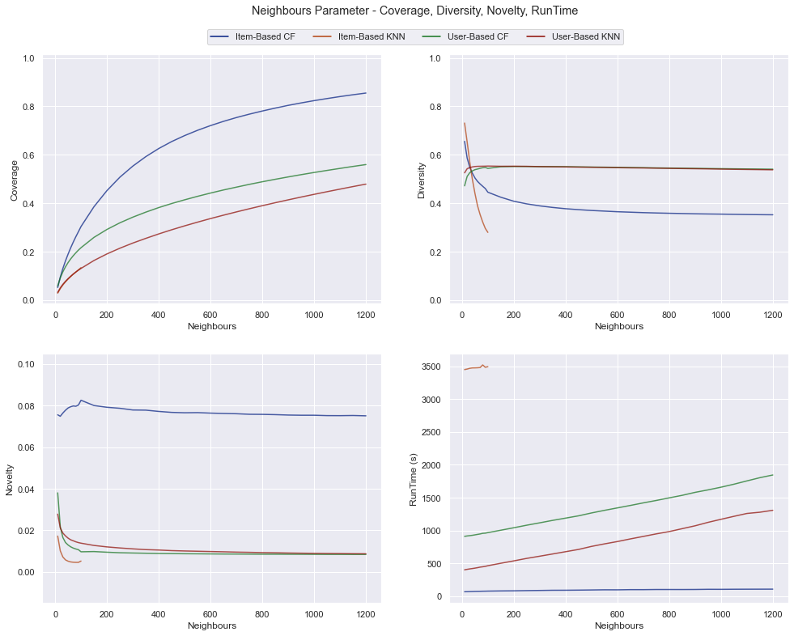

```python
# Coverage, Diversity, Novelty, Runtimes

fig, ((ax1, ax2), (ax3, ax4)) = plt.subplots(2, 2, figsize=(16, 12))
ax1 = sns.lineplot(data=neighboursTest_limit, x="ParameterValue", y="Coverage", hue="Algorithm", palette="dark", alpha=.7, ax=ax1)
ax2 = sns.lineplot(data=neighboursTest_limit, x="ParameterValue", y="Diversity", hue="Algorithm", palette="dark", alpha=.7, ax=ax2)
ax3 = sns.lineplot(data=neighboursTest_limit, x="ParameterValue", y="Novelty", hue="Algorithm", palette="dark", alpha=.7, ax=ax3)
ax4 = sns.lineplot(data=neighboursTest_limit, x="ParameterValue", y="TotalTime/s", hue="Algorithm", palette="dark", alpha=.7, ax=ax4)

fig.suptitle('Neighbours Parameter - Coverage, Diversity, Novelty, RunTime')
ax1.set(xlabel='Neighbours', ylabel='Coverage', ylim=(-0.015, 1.015))
ax2.set(xlabel='Neighbours', ylabel='Diversity', ylim=ax1.get_ylim())
ax3.set(xlabel='Neighbours', ylabel='Novelty', ylim=(-0.015, 0.105))
ax4.set(xlabel='Neighbours', ylabel='RunTime (s)')

fig.subplots_adjust(top=0.91, left=0.1, right=0.9)
ax1.legend(loc='center', bbox_to_anchor=(1.1, 1.07), ncol=5)
ax2.get_legend().remove()
ax3.get_legend().remove()
ax4.get_legend().remove()

plt.show()
fig.savefig('output/Neighbours_CDNT.jpg', format='jpeg', dpi=200, bbox_inches='tight')
```

While the hit rate metrics seemed to indicate user-based KNN and item-based CF as being preferable at lower parameter values, they do not perform so well when considering coverage. Due to the algorithm considering less neighbours, it is able to pull less items from the 'long-tail' of movies available in the database. This may not be best for a business looking to increase profits by recommending items from this 'long-tail' from which they may have greater profit margins. However, the greater diversities at these lower parameter values may increase user engagement as the items are not too closely related, hence making it less likely the user will have already seen the movies being recommended. Furthermore, item-based CF appears to return the most novel (i.e. 'long-tail') items in all cases.

Which is best here will be determined by the aims of the business: Do we want the algorithm to have greater coverage of our database? Do we want to increase customer engagement with more diverse recommendations? Or do we want to increase profit margins by recommending more niche movies?

### Reducing the input user's ratings to some threshold rating

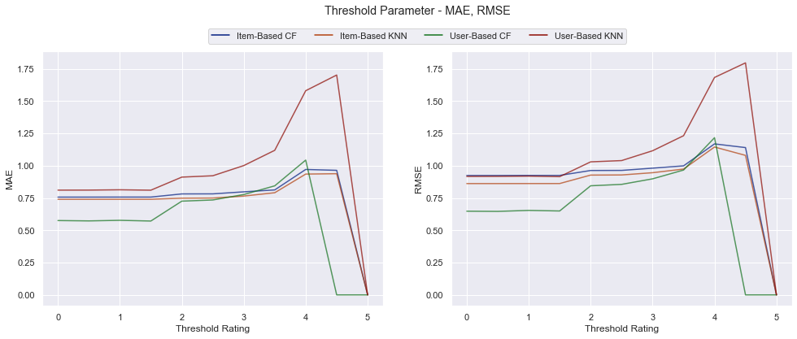

```python
# plot MAE and RMSE on subplots

fig, (ax1, ax2) = plt.subplots(1, 2, figsize=(16, 6))
ax1 = sns.lineplot(data=thresholdTest, x="ParameterValue", y="MAE", hue="Algorithm", palette="dark", alpha=.7, ax=ax1)
ax2 = sns.lineplot(data=thresholdTest, x="ParameterValue", y="RMSE", hue="Algorithm", palette="dark", alpha=.7, ax=ax2)

fig.suptitle('Threshold Parameter - MAE, RMSE')
ax1.set(xlabel='Threshold Rating', ylabel='MAE', ylim=(None, ax2.get_ylim()[1]))
ax2.set(xlabel='Threshold Rating', ylabel='RMSE', ylim=ax1.get_ylim())

fig.subplots_adjust(top=0.85, left=0.1, right=0.9)
ax1.legend(loc='center', bbox_to_anchor=(1.1, 1.06), ncol=5)
ax2.get_legend().remove()

plt.show()
fig.savefig('output/Threshold_MAE+RMSE.jpg', format='jpeg', dpi=200, bbox_inches='tight')
```

A clear preference for lower thresholds in terms of MAE and RMSE. All algorithms fall to 0 by the end as a threshold of 5 rarely returns enough items for the algorithms to make recommendations with, hence no rating predictions to calculate metrics for.

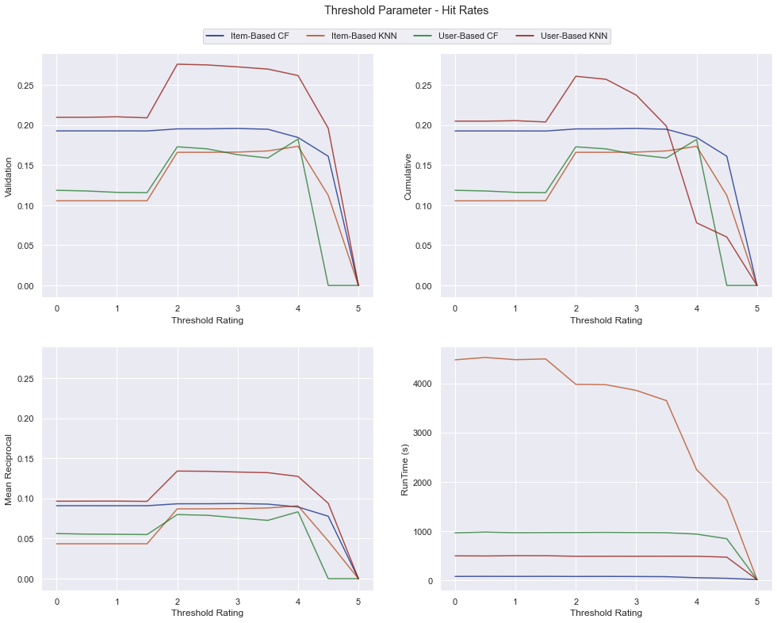

```python
# HitRates - Validation, Cumulative, Mean Reciprocal, Runtimes

fig, ((ax1, ax2), (ax3, ax4)) = plt.subplots(2, 2, figsize=(16, 12))
ax1 = sns.lineplot(data=thresholdTest, x="ParameterValue", y="Validation_HR", hue="Algorithm", palette="dark", alpha=.7, ax=ax1)
ax2 = sns.lineplot(data=thresholdTest, x="ParameterValue", y="Cumulative_HR", hue="Algorithm", palette="dark", alpha=.7, ax=ax2)
ax3 = sns.lineplot(data=thresholdTest, x="ParameterValue", y="MeanReciprocal_HR", hue="Algorithm", palette="dark", alpha=.7, ax=ax3)
ax4 = sns.lineplot(data=thresholdTest, x="ParameterValue", y="TotalTime/s", hue="Algorithm", palette="dark", alpha=.7, ax=ax4)

fig.suptitle('Threshold Parameter - Hit Rates')
ax1.set(xlabel='Threshold Rating', ylabel='Validation', ylim=(-0.015, None))
ax2.set(xlabel='Threshold Rating', ylabel='Cumulative', ylim=ax1.get_ylim())
ax3.set(xlabel='Threshold Rating', ylabel='Mean Reciprocal', ylim=ax1.get_ylim())
ax4.set(xlabel='Threshold Rating', ylabel='RunTime (s)')

fig.subplots_adjust(top=0.91, left=0.1, right=0.9)
ax1.legend(loc='center', bbox_to_anchor=(1.1, 1.07), ncol=5)
ax2.get_legend().remove()
ax3.get_legend().remove()
ax4.get_legend().remove()

plt.show()
fig.savefig('output/Threshold_HitRates.jpg', format='jpeg', dpi=200, bbox_inches='tight')
```

Here, most algorithms have a clear preference for 2.0 as the threshold rating. This parameter also has some positive impacts on the performance of the item-based KNN algorithm.

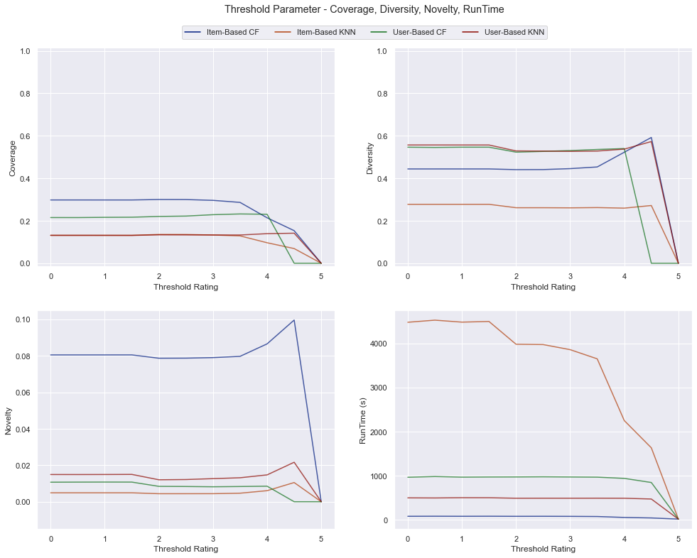

```python
# Coverage, Diversity, Novelty, Runtimes

fig, ((ax1, ax2), (ax3, ax4)) = plt.subplots(2, 2, figsize=(16, 12))
ax1 = sns.lineplot(data=thresholdTest, x="ParameterValue", y="Coverage", hue="Algorithm", palette="dark", alpha=.7, ax=ax1)
ax2 = sns.lineplot(data=thresholdTest, x="ParameterValue", y="Diversity", hue="Algorithm", palette="dark", alpha=.7, ax=ax2)
ax3 = sns.lineplot(data=thresholdTest, x="ParameterValue", y="Novelty", hue="Algorithm", palette="dark", alpha=.7, ax=ax3)
ax4 = sns.lineplot(data=thresholdTest, x="ParameterValue", y="TotalTime/s", hue="Algorithm", palette="dark", alpha=.7, ax=ax4)

fig.suptitle('Threshold Parameter - Coverage, Diversity, Novelty, RunTime')
ax1.set(xlabel='Threshold Rating', ylabel='Coverage', ylim=(-0.015, 1.015))
ax2.set(xlabel='Threshold Rating', ylabel='Diversity', ylim=ax1.get_ylim())
ax3.set(xlabel='Threshold Rating', ylabel='Novelty', ylim=(-0.015, 0.105))
ax4.set(xlabel='Threshold Rating', ylabel='RunTime (s)')

fig.subplots_adjust(top=0.91, left=0.1, right=0.9)
ax1.legend(loc='center', bbox_to_anchor=(1.1, 1.07), ncol=5)
ax2.get_legend().remove()
ax3.get_legend().remove()
ax4.get_legend().remove()

plt.show()
fig.savefig('output/Threshold_CDNT.jpg', format='jpeg', dpi=200, bbox_inches='tight')
```

### The sample parameter

The maximum value for the sample parameter will be the value set for the maximum user ratings when initially limiting our data set for building the ratings pivot table, in this case 6000. Once again, computational limitations mean we shall only be testing up to 1200 for all algorithms, and up to 100 for the Item-Based KNN algorithm due to its significantly slower runtimes.

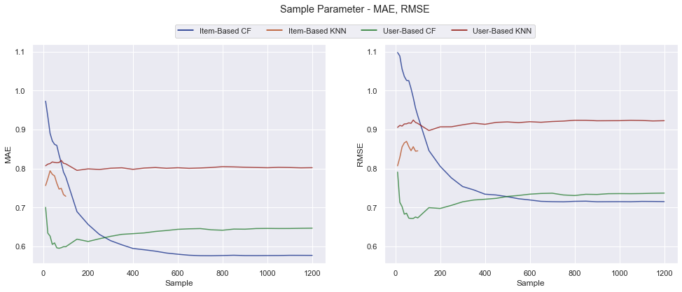

```python
# plot MAE and RMSE on subplots

fig, (ax1, ax2) = plt.subplots(1, 2, figsize=(16, 6))
ax1 = sns.lineplot(data=sampleTest, x="ParameterValue", y="MAE", hue="Algorithm", palette="dark", alpha=.7, ax=ax1)
ax2 = sns.lineplot(data=sampleTest, x="ParameterValue", y="RMSE", hue="Algorithm", palette="dark", alpha=.7, ax=ax2)

fig.suptitle('Sample Parameter - MAE, RMSE')
ax1.set(xlabel='Sample', ylabel='MAE', ylim=(None, ax2.get_ylim()[1]))
ax2.set(xlabel='Sample', ylabel='RMSE', ylim=ax1.get_ylim())

fig.subplots_adjust(top=0.85, left=0.1, right=0.9)
ax1.legend(loc='center', bbox_to_anchor=(1.1, 1.06), ncol=5)
ax2.get_legend().remove()

plt.show()
fig.savefig('output/Sample_MAE+RMSE.jpg', format='jpeg', dpi=200, bbox_inches='tight')
```

Errors for user-based KNN are largely unaffected by the sample parameter, with item-based-CF preferring far higher values, and user-based CF preferring lower values of around 70-90. Item-based KNN appears to prefer higher values, however we will soon see next the impact higher values has on run-times.

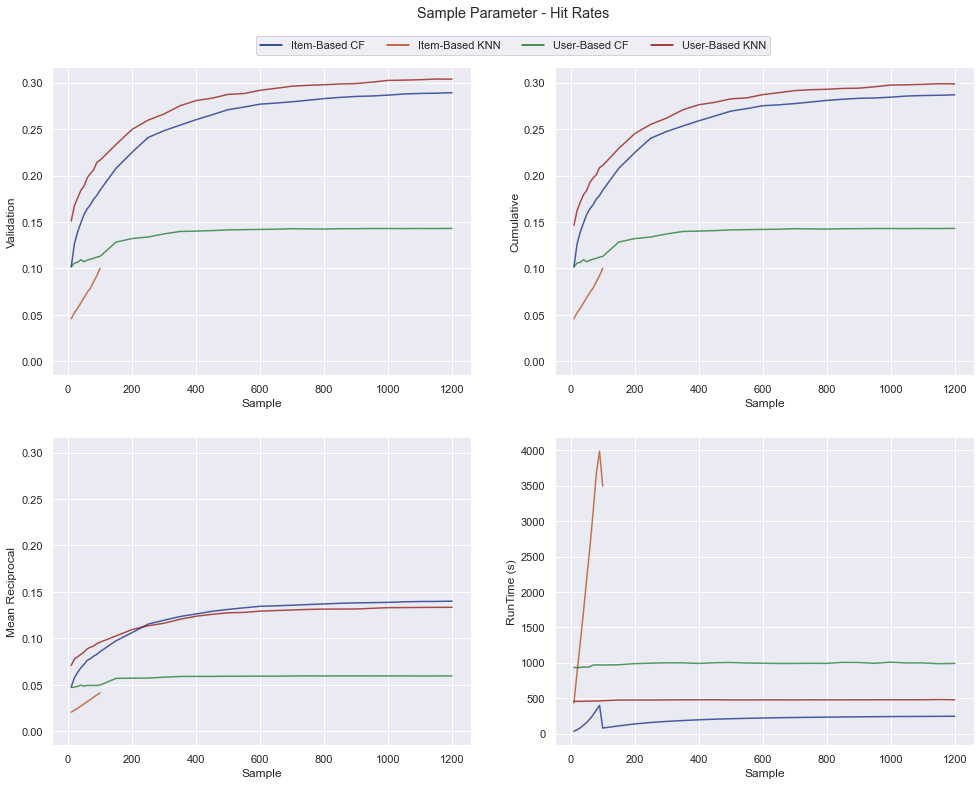

```python
# HitRates - Validation, Cumulative, Mean Reciprocal, Runtimes

fig, ((ax1, ax2), (ax3, ax4)) = plt.subplots(2, 2, figsize=(16, 12))
ax1 = sns.lineplot(data=sampleTest, x="ParameterValue", y="Validation_HR", hue="Algorithm", palette="dark", alpha=.7, ax=ax1)
ax2 = sns.lineplot(data=sampleTest, x="ParameterValue", y="Cumulative_HR", hue="Algorithm", palette="dark", alpha=.7, ax=ax2)
ax3 = sns.lineplot(data=sampleTest, x="ParameterValue", y="MeanReciprocal_HR", hue="Algorithm", palette="dark", alpha=.7, ax=ax3)
ax4 = sns.lineplot(data=sampleTest, x="ParameterValue", y="TotalTime/s", hue="Algorithm", palette="dark", alpha=.7, ax=ax4)

fig.suptitle('Sample Parameter - Hit Rates')
ax1.set(xlabel='Sample', ylabel='Validation', ylim=(-0.015, None))
ax2.set(xlabel='Sample', ylabel='Cumulative', ylim=ax1.get_ylim())
ax3.set(xlabel='Sample', ylabel='Mean Reciprocal', ylim=ax1.get_ylim())
ax4.set(xlabel='Sample', ylabel='RunTime (s)')

fig.subplots_adjust(top=0.91, left=0.1, right=0.9)
ax1.legend(loc='center', bbox_to_anchor=(1.1, 1.07), ncol=5)
ax2.get_legend().remove()
ax3.get_legend().remove()
ax4.get_legend().remove()

plt.show()
fig.savefig('output/Sample_HitRates.jpg', format='jpeg', dpi=200, bbox_inches='tight')
```

Item-based KNN shows a linear increase in run-time for this parameter showing its impracticality once again. Run-times for all other algorithms remain largely unaffected though.

In terms of hit rates, all algorithms see greater quality in recommendations for higher parameter values, despite this increasing rating prediction errors in some cases. Item-based CF and user-based KNN would be the best choice here, with higher values of over 1000 preferred.

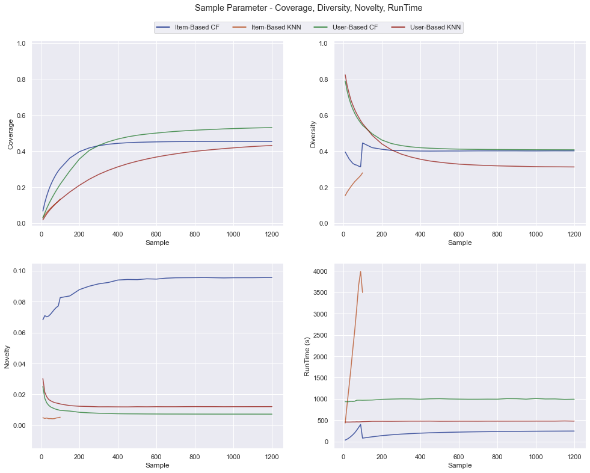

```python
# Coverage, Diversity, Novelty, Runtimes

fig, ((ax1, ax2), (ax3, ax4)) = plt.subplots(2, 2, figsize=(16, 12))
ax1 = sns.lineplot(data=sampleTest, x="ParameterValue", y="Coverage", hue="Algorithm", palette="dark", alpha=.7, ax=ax1)
ax2 = sns.lineplot(data=sampleTest, x="ParameterValue", y="Diversity", hue="Algorithm", palette="dark", alpha=.7, ax=ax2)
ax3 = sns.lineplot(data=sampleTest, x="ParameterValue", y="Novelty", hue="Algorithm", palette="dark", alpha=.7, ax=ax3)
ax4 = sns.lineplot(data=sampleTest, x="ParameterValue", y="TotalTime/s", hue="Algorithm", palette="dark", alpha=.7, ax=ax4)

fig.suptitle('Sample Parameter - Coverage, Diversity, Novelty, RunTime')
ax1.set(xlabel='Sample', ylabel='Coverage', ylim=(-0.015, 1.015))
ax2.set(xlabel='Sample', ylabel='Diversity', ylim=ax1.get_ylim())
ax3.set(xlabel='Sample', ylabel='Novelty', ylim=(-0.015, 0.105))
ax4.set(xlabel='Sample', ylabel='RunTime (s)')

fig.subplots_adjust(top=0.91, left=0.1, right=0.9)
ax1.legend(loc='center', bbox_to_anchor=(1.1, 1.07), ncol=5)
ax2.get_legend().remove()
ax3.get_legend().remove()
ax4.get_legend().remove()

plt.show()
fig.savefig('output/Sample_CDNT.jpg', format='jpeg', dpi=200, bbox_inches='tight')
```

We once again see a similar trade-off between coverage, diversity and novelty as we saw with the neighbours parameter, with similar questions that need to be answered by the business to determine which is best for their aims. However, one difference we do see here is how coverage can be greatly improved for the user-based CF model by increasing the sample size.

## Fine-tuning the chosen algorithms

Given the above results, we'll be considering a business with the aim of recommending items that users are most-likely to watch, while having the greatest coverage of the items in their database. It will show two sets of recommendations: the item-based CF algorithm will show recommendations that draw more from the 'long-tail' of items to help increase profits, and the user-based KNN algorithm will show a set of recommendations the user is more likely to watch and rate highly.

While testing of the rating predictions parameter indicated that mean ratings produced the least errors, running the following tests with the other parameters fine-tuned returned preferable results for the calculated ratings in item-based CF as seen below.

As such, the following parameter will be used in the final tests:

- Item-Based CF: {'neighbours': 1000, 'sample': 1000, 'threshold': 2.0, 'predict': 'calc'}
- User-Based KNN: {'neighbours': 20, 'sample': 1000, 'threshold': 2.0, 'predict': 'mean'}

```python
# run tests
filename = 'ML_MetricsData'
evaluator = Tester.Metrics(validation, LOO_dropped, topN=30, moviesPerPage=5, thresholdRating=3.0, csvName=filename)
tester = Tester.Tester(evaluator)

tester.addAlgorithm('Item-Based CF', algo.itemBased, model=CF_itemModel, modelType='CF',
                    neighbours=1000, sample=1000, threshold=2.0)
tester.addAlgorithm('User-Based KNN', algo.userBased, model=KNN_userModel, modelType='KNN',
                    neighbours=20, sample=1000, threshold=2.0)
tester.addAlgorithm('Random Control', algo.random, randomRatings=True)

parameter = 'predict'
pRange = ['calc', 'mean']

tester.runParameterTest(test, LOOCV=False, param=parameter, pRange=pRange, printResults=False)
tester.runParameterTest(LOO_test, LOOCV=True, param=parameter, pRange=pRange, printResults=False)
```

```
ML_MetricsData.csv already exists. Update this file (u) or overwrite (o)? u
Added Item-Based CF
Added User-Based KNN
Added Random Control
```

```python
# import data and split
with open('output/ML_MetricsData.csv', encoding="UTF-8") as file:  # read into data frame format
    data = pd.read_csv(file).iloc[298:310].reset_index(drop=True)

ratingRetest = data[data['ParameterTest'] == 'predict']
ratingRetest = ratingRetest[ratingRetest['LOOCV_HR'].isna()]
ratingRetest = ratingRetest[['Algorithm', 'ParameterTest', 'ParameterValue', 'MAE', 'RMSE']]

# drop extra columns
data = data.drop(['Top-N', 'MoviesPerPage', 'ThresholdRating', 'TotalIDs', 'ParameterTest',
                  'ParameterValue', 'OtherParameters', 'TotalTime/s'], axis=1)
ratingRetest
```

|  | Algorithm | ParameterTest | ParameterValue | MAE | RMSE |
| --- | --- | --- | --- | --- | --- |
| 0 | Item-Based CF | predict | mean | 0.690324 | 0.804269 |
| 1 | User-Based KNN | predict | mean | 0.662175 | 0.784425 |
| 6 | Item-Based CF | predict | calc | 0.571555 | 0.701737 |
| 7 | User-Based KNN | predict | calc | 0.807781 | 0.928417 |

As we can see above, MAE is far lower for calculated predicted ratings in the case of item-based CF. However, user-based KNN still benefits from using mean ratings as the predictor.

```python
# retain validation test results with previously discussed rating prediction algorithms
results = data.iloc[[6, 1, 2]].dropna(axis=1).set_index('Algorithm')
actualRatings = pd.DataFrame()

for name in results.index:
    d = literal_eval(results.at[name, 'ActualRating_HR'])
    actualRatings[name] = pd.Series(d)

# split data and melt data for plotting in groups
times = results['MeanTime/s']

results = results.drop(['ActualRating_HR', 'MeanTime/s'], axis=1).T.reset_index().rename({'index': 'Metrics'}, axis=1)
results = pd.melt(results, id_vars="Metrics", var_name="Algorithm", value_name="Values")

actualRatings = actualRatings.reset_index().rename({'index': 'Rating'}, axis=1)
actualRatings = pd.melt(actualRatings, id_vars="Rating", var_name="Algorithm", value_name="Values")
actualRatings['Values'] = actualRatings['Values'].multiply(100)
```

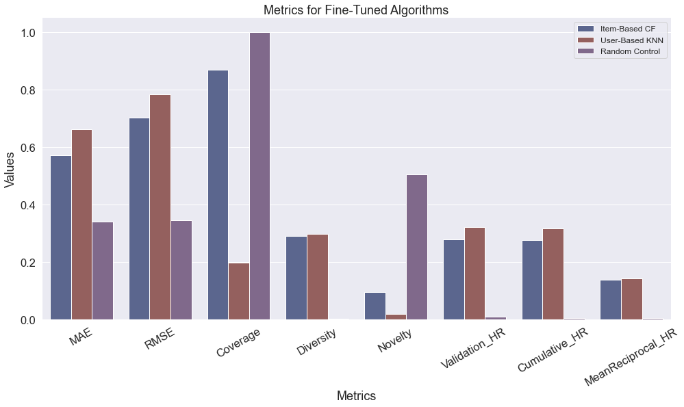

```python
# plot all metrics for validation test
sns.set(font_scale=1.5)

g = sns.factorplot(x='Metrics', y='Values', hue='Algorithm', data=results, kind='bar',
                   palette=["#526196", "#9D5755", "#826391"], size=7, aspect=2, legend=False)
g.ax.set_title('Metrics for Fine-Tuned Algorithms', size=18)
g.ax.legend(loc='upper right', fontsize=12)
g.set_xticklabels(rotation=30)

plt.show()
g.savefig('output/FinalTest_Metrics.jpg', format='jpeg', dpi=200, bbox_inches='tight')
```

MAE and RMSE now show modest values of around 0.6 and 0.75 respectively, returning some of the most accurate results seen for each of these algorithms. Interestingly though, the random control appears to out-perform both algorithms which was not the case when controlling the rating prediction parameter earlier.

As intended, the CF model has high coverage at around 0.85, whereas the KNN algorithm has lower coverage at 0.2. Naturally, the random control is able to recommend the full set of items available. Diversity for both is around 0.3, a moderately low value which shows recommendations that may make good sense for the user, but that they may have already seen due to occurrences of sequels or otherwise. However, high values would be very difficult to achieve for a system that also recommends movies the user actually likes, as most users have very specific tastes and will not like movies from largely disparate genres. We also see Novelty at around 0.1 for item-based CF which is around the highest value seen in testing.

The sweet spot for Novelty and Diversity, would only be found through A/B testing with real users. For Novelty, too low a value leads to a lack of niche item recommendations, whereas too high a value leads to lack of confidence in the recommendations from the user, and therefore, disengagement.

Hit Rates hover around the highest values seen in testing at around 0.3 for Validation and Cumulative. The fact that both of these are approximately equal shows that a majority of the recommendations have a rating prediction above the 3.0 threshold. This hit rate does drop off for Mean Reciprocal, showing many of our hits are appearing in lower page numbers, though it would be impossible to see a Mean Reciprocal hit rate comparable to Validation or Cumulative due to the nature of the calculation weighting hits fractionally per page they appear on.

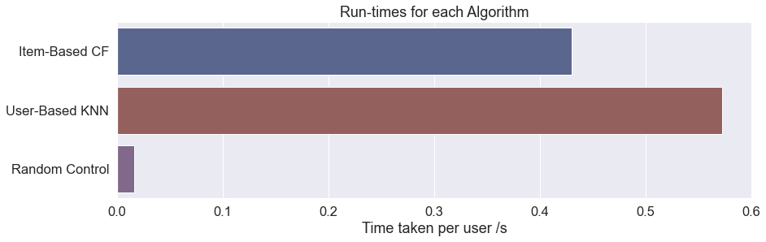

```python
# plot run-times
fig = plt.figure(figsize=(14, 4))
ax = sns.barplot(x=times.values, y=times.index, orient='h', palette=["#526196", "#9D5755", "#826391"])
ax.set(xlabel='Time taken per user /s', ylabel=None, title='Run-times for each Algorithm')

plt.show()
fig.savefig('output/FinalTest_TotalTime.jpg', format='jpeg', dpi=200, bbox_inches='tight')
```

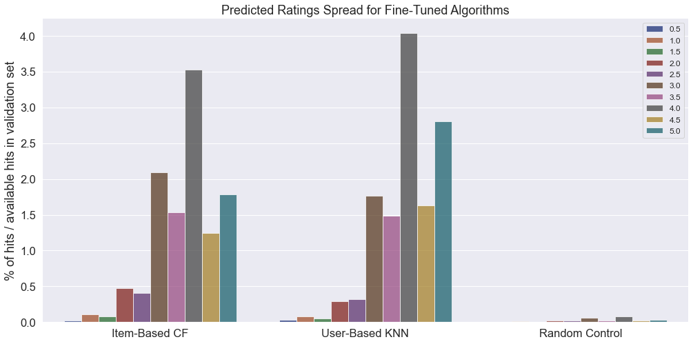

```python
# plot predicted ratings spread
g = sns.factorplot(x='Algorithm', y='Values', hue='Rating', data=actualRatings, kind='bar',
                   palette="dark", alpha=.7, size=7, aspect=2, legend=False)
g.ax.set_title('Predicted Ratings Spread for Fine-Tuned Algorithms', size=18)
g.set(xlabel=None, ylabel='% of hits / available hits in validation set')
g.ax.legend(loc='upper right', fontsize=12)

plt.show()
g.savefig('output/FinalTest_RatingsSpread.jpg', format='jpeg', dpi=200, bbox_inches='tight')
```

The algorithms return recommendations within 0.42s - 0.56s, with item-based CF performing slightly faster due to it being a memory-based model.

Finally, we can see the spread of rating predictions given to the hits, with most recommendations coming in above the 3.0 threshold rating as previously shown by the Cumulative HR metric. Both algorithms have a clear preference for recommending movies with predicted ratings of 4.0, which keeps in line with the graphs seen during the initial analysis of the data set for rating spreads amongst users.

## Conclusion

In this part of the project, we took the algorithms discussed in part 1 and tested the various parameters associated with each of them, covering the rating predictions algorithm, neighbours, sample and a threshold rating for the users rating. By graphing the results from these tests, we were able to decide the best algorithms and parameters to use for a given use case of recommending movies the user likes, with consideration given to the coverage and ability to recommend from the 'long-tail' of items in the database. The following two algorithms and parameters were decided as most appropriate for this use-case:

- Item-Based CF: {'neighbours': 1000, 'sample': 1000, 'threshold': 2.0, 'predict': 'calc'}
- User-Based KNN: {'neighbours': 20, 'sample': 1000, 'threshold': 2.0, 'predict': 'mean'}

Repeating tests for these algorithms gave us the optimal quality of recommendations possible for this program.

While we were able to conduct tests on a limited version of the data set, further tests can look at using a greater sample, or even all, of the data set to rigorously test the algorithms. Furthermore, tests on the item-based KNN were largely impractical given the available resources, hence future tests could analyse this more rigorously. However, this algorithm may prove to be impractical for production code anyway due to its significantly higher run-times.

Further improvements to this recommendations system could factor in other algorithms or aspects related to the items or users. Such advanced techniques include:

- matrix decomposition methods such as SVD which separates the ratings pivot table up into its constituent parts to simplify calculations and enables us to draw hidden information contained in the original data
- mise en scène data which can be used to predict similarities between movies using visual data from the movie
- translation based recommendations which aims to embed items in a 'translation space' where each user is modelled by a translation vector. This allows us to pull recommendations for the user by just nearby movies found on this translation vector